# Bootstrapping Diabetes Data to Illuminate Factors

## Dataset Overview

We got our dataset from kaggle:

The dataset consisted of health indicators for people with no diabetes, prediabetes, and diabetes.

We chose to focus on the variables HighBP, HighChol, BMI, AnyHealthcare, GenHlth, and Income out of the 21 factors in the dataset

- High BP, HighChol, and AnyHealthcare are binary
- GenHlth has 5 levels
- BMI and Income are continuous

We decided to bootstrap our data because there was a massive difference in sample sizes for the 3 classifications of patients

Each of us did a different kind of bootsrapping method

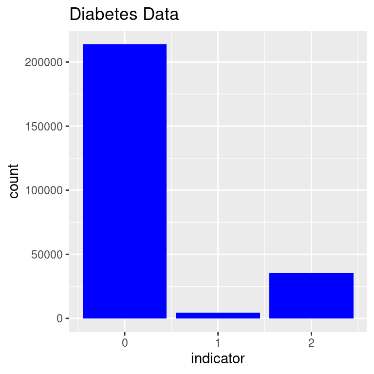

## Percentile and Basic Bootstraps

- I analyzed the variables HighBP, HighChol, BMI, AnyHealthcare, GenHlth, and Income for differences in means among no diabetes, prediabetes, and diabetes.
- Overall, I found that there was a significant difference in most of the means. The only means that i didn’t see a difference in were some of the AnyHealthcare CI’s
- There was small difference between the CI’s for the percentile and basic bootstraps which matched my findings for small bias

## Tables for means and CI’s no - pre

no-pre

|  | mean | low percentile | high percentile | low basic | high basic |
| --- | --- | --- | --- | --- | --- |
| HighBP | -0.258 | -0.272 | -0.244 | -0.272 | -0.243 |
| HighChol | -0.241 | -0.255 | -0.227 | -0.257 | -0.228 |
| BMI | -2.984 | -3.173 | -2.783 | -3.181 | -2.791 |
| AnyHealthcare | 0.005 | -0.002 | 0.011 | -0.002 | 0.011 |
| GenHlth | -0.603 | -0.632 | -0.572 | -0.635 | -0.575 |
| Income | 0.857 | 0.790 | 0.920 | 0.795 | 0.925 |

## Tables for means and CI’s pre - diab

pre-diab

[output not shown]

## Tables for means and CI’s diab - no

diab-no

[output not shown]

## AnyHealthcare No Diabetes and Prediabetes

```
## [[1]]
## BOOTSTRAP CONFIDENCE INTERVAL CALCULATIONS
## Based on 1000 bootstrap replicates
##
## CALL :
## boot.ci(boot.out = no_pre, type = c("perc", "basic"))
##
## Intervals :
## Level      Basic              Percentile
## 95%   (-0.0020,  0.0108 )   (-0.0016,  0.0112 )
## Calculations and Intervals on Original Scale
```

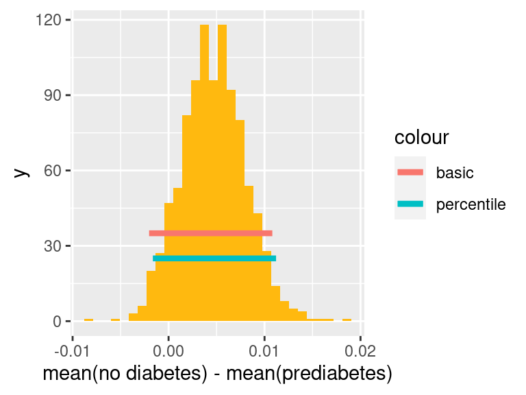

## AnyHealthcare Prediabetes and Diabetes

```
## [[1]]
## BOOTSTRAP CONFIDENCE INTERVAL CALCULATIONS
## Based on 1000 bootstrap replicates
##
## CALL :
## boot.ci(boot.out = pre_diab, type = c("perc", "basic"))
##
## Intervals :
## Level      Basic              Percentile
## 95%   (-0.0216, -0.0079 )   (-0.0213, -0.0076 )
## Calculations and Intervals on Original Scale
```

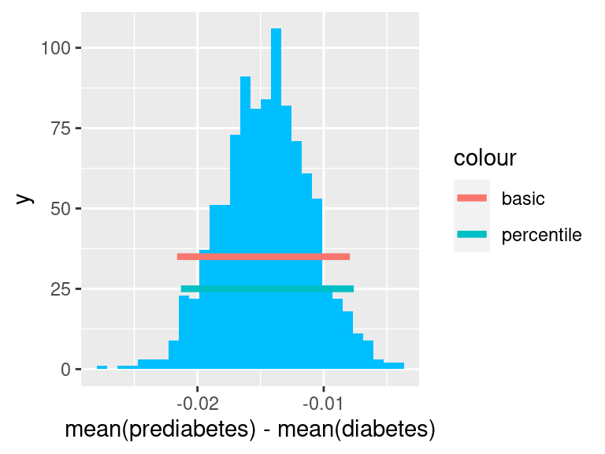

## AnyHealthcare Diabetes and No Diabetes

```
## [[1]]
## BOOTSTRAP CONFIDENCE INTERVAL CALCULATIONS
## Based on 1000 bootstrap replicates
##
## CALL :
## boot.ci(boot.out = diab_no, type = c("perc", "basic"))
##
## Intervals :
## Level      Basic              Percentile
## 95%   ( 0.0078,  0.0122 )   ( 0.0078,  0.0123 )
## Calculations and Intervals on Original Scale
```

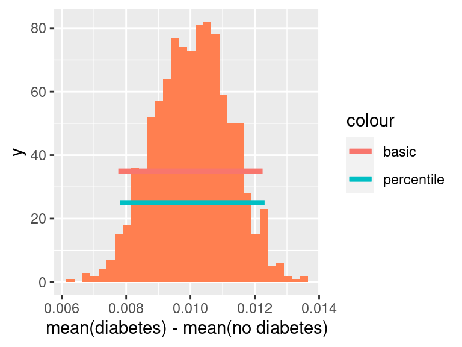

```
## [[1]]
## BOOTSTRAP CONFIDENCE INTERVAL CALCULATIONS
## Based on 1000 bootstrap replicates
##
## CALL :
## boot.ci(boot.out = no_pre, type = c("perc", "basic"))
##
## Intervals :
## Level      Basic              Percentile
## 95%   (-0.2723, -0.2434 )   (-0.2724, -0.2435 )
## Calculations and Intervals on Original Scale
```

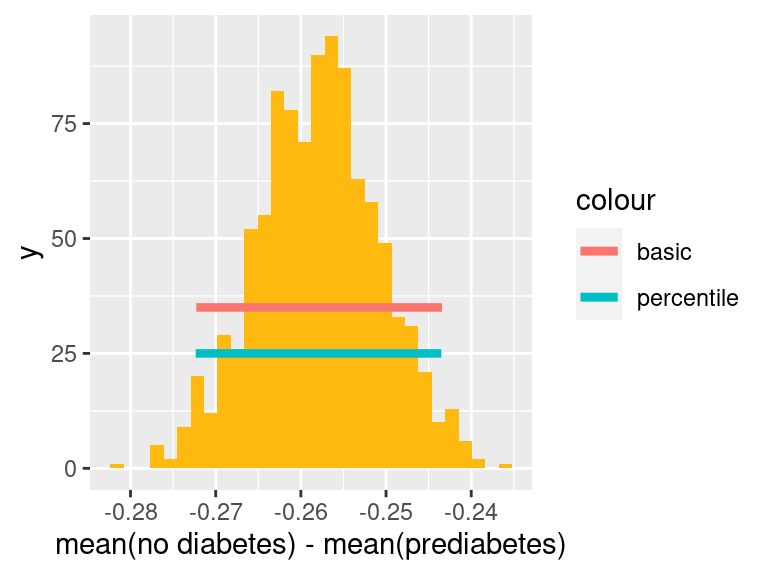

```
## [[1]]
## BOOTSTRAP CONFIDENCE INTERVAL CALCULATIONS
## Based on 1000 bootstrap replicates
##
## CALL :
## boot.ci(boot.out = pre_diab, type = c("perc", "basic"))
##
## Intervals :
## Level      Basic              Percentile
## 95%   (-0.1382, -0.1097 )   (-0.1376, -0.1091 )
## Calculations and Intervals on Original Scale
```

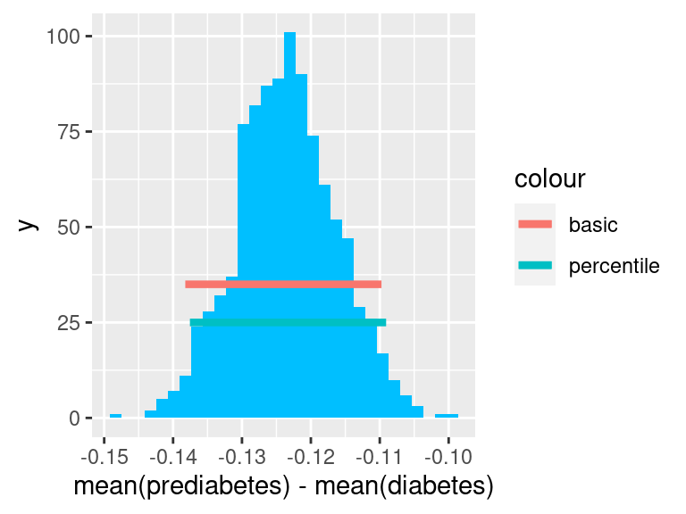

```
## [[1]]
## BOOTSTRAP CONFIDENCE INTERVAL CALCULATIONS
## Based on 1000 bootstrap replicates
##
## CALL :
## boot.ci(boot.out = diab_no, type = c("perc", "basic"))
##
## Intervals :
## Level      Basic              Percentile
## 95%   ( 0.3770,  0.3865 )   ( 0.3766,  0.3861 )
## Calculations and Intervals on Original Scale
```

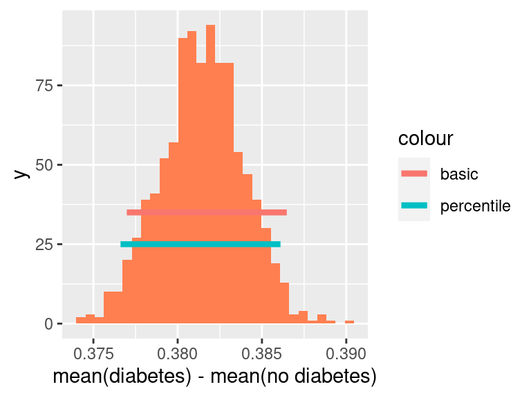

## Standard Normal Bootstrap CI

- We used a Standard Normal Bootstrap for each classification, (No Diabetes, Pre-Diabetes, and Diabetes), and pulled out our factors of interest, (Income, BMI, GenHlth, HighBP, and AnyHealthcare).
- We also used different values of sample size, `n`, and number of samples, `m`, to showcase the power of bootstrapping with Normal distributions

### Assumptions:

- Need \(\hat{\theta}\sim N(E[\hat{\theta}],\,\hat{\text{se}}(\hat{\theta})^2)\)
- Need \(\hat{\theta}\) to be unbiased
- Large sample size

## Pairs of `m` and `n` values

Tables of standard error of our estimators

Income and No Diabetes

|  | n=10 | n=25 | n=75 | n=125 | n=250 |
| --- | --- | --- | --- | --- | --- |
| m=10 | 0.549 | 0.481 | 0.252 | 0.228 | 0.091 |
| m=30 | 0.888 | 0.465 | 0.285 | 0.203 | 0.150 |
| m=50 | 0.719 | 0.465 | 0.306 | 0.243 | 0.154 |
| m=100 | 0.741 | 0.484 | 0.285 | 0.204 | 0.163 |
| m=250 | 0.743 | 0.479 | 0.264 | 0.199 | 0.150 |

Income and Pre-Diabetes

|  | n=10 | n=25 | n=75 | n=125 | n=250 |
| --- | --- | --- | --- | --- | --- |
| m=10 | 0.523 | 0.279 | 0.147 | 0.148 | 0.147 |
| m=30 | 0.542 | 0.402 | 0.227 | 0.185 | 0.112 |
| m=50 | 0.645 | 0.357 | 0.213 | 0.195 | 0.130 |
| m=100 | 0.625 | 0.390 | 0.238 | 0.182 | 0.137 |
| m=250 | 0.605 | 0.384 | 0.230 | 0.171 | 0.126 |

Income and Diabetes

|  | n=10 | n=25 | n=75 | n=125 | n=250 |
| --- | --- | --- | --- | --- | --- |
| m=10 | 0.520 | 0.371 | 0.151 | 0.132 | 0.149 |
| m=30 | 0.617 | 0.475 | 0.289 | 0.218 | 0.114 |
| m=50 | 0.777 | 0.452 | 0.263 | 0.174 | 0.107 |
| m=100 | 0.773 | 0.399 | 0.213 | 0.201 | 0.164 |
| m=250 | 0.646 | 0.453 | 0.265 | 0.201 | 0.144 |

HighBP and No Diabetes

|  | n=10 | n=25 | n=75 | n=125 | n=250 |
| --- | --- | --- | --- | --- | --- |
| m=10 | 0.187 | 0.092 | 0.056 | 0.061 | 0.035 |
| m=30 | 0.163 | 0.092 | 0.048 | 0.041 | 0.032 |
| m=50 | 0.165 | 0.096 | 0.061 | 0.043 | 0.031 |
| m=100 | 0.151 | 0.088 | 0.054 | 0.042 | 0.034 |
| m=250 | 0.153 | 0.098 | 0.057 | 0.046 | 0.032 |

HighBP and Pre-Diabetes

|  | n=10 | n=25 | n=75 | n=125 | n=250 |
| --- | --- | --- | --- | --- | --- |
| m=10 | 0.067 | 0.071 | 0.065 | 0.038 | 0.025 |
| m=30 | 0.156 | 0.093 | 0.054 | 0.035 | 0.030 |
| m=50 | 0.158 | 0.089 | 0.060 | 0.042 | 0.028 |
| m=100 | 0.147 | 0.102 | 0.056 | 0.040 | 0.024 |
| m=250 | 0.158 | 0.091 | 0.056 | 0.044 | 0.031 |

HighBP and Diabetes

|  | n=10 | n=25 | n=75 | n=125 | n=250 |
| --- | --- | --- | --- | --- | --- |
| m=10 | 0.107 | 0.053 | 0.031 | 0.040 | 0.019 |
| m=30 | 0.121 | 0.063 | 0.045 | 0.023 | 0.028 |
| m=50 | 0.115 | 0.058 | 0.035 | 0.031 | 0.023 |
| m=100 | 0.116 | 0.063 | 0.039 | 0.034 | 0.021 |
| m=250 | 0.108 | 0.067 | 0.040 | 0.030 | 0.021 |

AnyHealthcare and No Diabetes

|  | n=10 | n=25 | n=75 | n=125 | n=250 |
| --- | --- | --- | --- | --- | --- |
| m=10 | 0.052 | 0.035 | 0.019 | 0.020 | 0.019 |
| m=30 | 0.077 | 0.051 | 0.021 | 0.022 | 0.013 |
| m=50 | 0.059 | 0.048 | 0.026 | 0.017 | 0.012 |
| m=100 | 0.060 | 0.043 | 0.022 | 0.017 | 0.013 |
| m=250 | 0.070 | 0.044 | 0.024 | 0.019 | 0.014 |

AnyHealthcare and Pre-Diabetes

|  | n=10 | n=25 | n=75 | n=125 | n=250 |
| --- | --- | --- | --- | --- | --- |
| m=10 | 0.042 | 0.060 | 0.024 | 0.017 | 0.018 |
| m=30 | 0.057 | 0.039 | 0.021 | 0.018 | 0.012 |
| m=50 | 0.073 | 0.047 | 0.022 | 0.019 | 0.012 |
| m=100 | 0.070 | 0.039 | 0.024 | 0.021 | 0.014 |
| m=250 | 0.066 | 0.043 | 0.024 | 0.018 | 0.012 |

AnyHealthcare and Diabetes

|  | n=10 | n=25 | n=75 | n=125 | n=250 |
| --- | --- | --- | --- | --- | --- |
| m=10 | 0 | 0 | 0 | 0 | 0 |
| m=30 | 0 | 0 | 0 | 0 | 0 |
| m=50 | 0 | 0 | 0 | 0 | 0 |
| m=100 | 0 | 0 | 0 | 0 | 0 |
| m=250 | 0 | 0 | 0 | 0 | 0 |

## Bootstrap t CI

- We used Student-t Bootstraping for each classification, (No Diabetes, Pre-Diabetes, and Diabetes), and pulled out our factors of interest, (Income, BMI, GenHlth, HighBP, and AnyHealthcare).
- We also used different values of sample size, `n`, and number of samples, `m`, to showcase the difference of double bootstrapping with Student-t distributions
- We wanted to show that larger and more samples decreased our standard error of our estimator

### Assumptions:

- Small bias and skewness of \(\hat{\theta}\)
- Need \(\hat{\theta}\) independent of \(\hat{\text{se}}(\hat{\theta})\)

## Pairs of `m` and `n` values

Tables of standard error of our estimators

Income and No Diabetes

|  | n=10 | n=25 | n=75 | n=125 | n=250 |
| --- | --- | --- | --- | --- | --- |
| m=10 | 0.784 | 0.493 | 0.205 | 0.180 | 0.139 |
| m=30 | 0.743 | 0.425 | 0.277 | 0.241 | 0.166 |
| m=50 | 0.845 | 0.547 | 0.289 | 0.180 | 0.133 |
| m=100 | 0.781 | 0.457 | 0.278 | 0.225 | 0.160 |
| m=250 | 0.816 | 0.473 | 0.274 | 0.216 | 0.144 |

Income and Pre-Diabetes

|  | n=10 | n=25 | n=75 | n=125 | n=250 |
| --- | --- | --- | --- | --- | --- |
| m=10 | 0.448 | 0.333 | 0.282 | 0.167 | 0.140 |
| m=30 | 0.626 | 0.356 | 0.230 | 0.193 | 0.153 |
| m=50 | 0.476 | 0.354 | 0.190 | 0.215 | 0.112 |
| m=100 | 0.641 | 0.402 | 0.211 | 0.190 | 0.110 |
| m=250 | 0.610 | 0.412 | 0.220 | 0.174 | 0.121 |

Income and Diabetes

|  | n=10 | n=25 | n=75 | n=125 | n=250 |
| --- | --- | --- | --- | --- | --- |
| m=10 | 0.416 | 0.289 | 0.299 | 0.271 | 0.115 |
| m=30 | 0.741 | 0.391 | 0.259 | 0.153 | 0.126 |
| m=50 | 0.610 | 0.466 | 0.221 | 0.200 | 0.135 |
| m=100 | 0.617 | 0.469 | 0.242 | 0.185 | 0.152 |
| m=250 | 0.669 | 0.443 | 0.248 | 0.211 | 0.127 |

HighBP and No Diabetes

|  | n=10 | n=25 | n=75 | n=125 | n=250 |
| --- | --- | --- | --- | --- | --- |
| m=10 | 0.158 | 0.087 | 0.052 | 0.050 | 0.023 |
| m=30 | 0.150 | 0.106 | 0.067 | 0.034 | 0.037 |
| m=50 | 0.152 | 0.098 | 0.065 | 0.043 | 0.027 |
| m=100 | 0.145 | 0.091 | 0.057 | 0.047 | 0.032 |
| m=250 | 0.146 | 0.099 | 0.056 | 0.043 | 0.031 |

HighBP and Pre-Diabetes

|  | n=10 | n=25 | n=75 | n=125 | n=250 |
| --- | --- | --- | --- | --- | --- |
| m=10 | 0.178 | 0.167 | 0.058 | 0.044 | 0.026 |
| m=30 | 0.171 | 0.103 | 0.047 | 0.048 | 0.033 |
| m=50 | 0.147 | 0.091 | 0.046 | 0.034 | 0.027 |
| m=100 | 0.153 | 0.089 | 0.062 | 0.044 | 0.033 |
| m=250 | 0.163 | 0.092 | 0.061 | 0.042 | 0.031 |

HighBP and Diabetes

|  | n=10 | n=25 | n=75 | n=125 | n=250 |
| --- | --- | --- | --- | --- | --- |
| m=10 | 0.103 | 0.091 | 0.040 | 0.035 | 0.019 |
| m=30 | 0.074 | 0.059 | 0.043 | 0.028 | 0.018 |
| m=50 | 0.133 | 0.067 | 0.047 | 0.029 | 0.025 |
| m=100 | 0.111 | 0.065 | 0.042 | 0.030 | 0.021 |
| m=250 | 0.120 | 0.068 | 0.040 | 0.031 | 0.022 |

AnyHealthcare and No Diabetes

|  | n=10 | n=25 | n=75 | n=125 | n=250 |
| --- | --- | --- | --- | --- | --- |
| m=10 | 0.067 | 0.033 | 0.023 | 0.017 | 0.017 |
| m=30 | 0.068 | 0.039 | 0.027 | 0.019 | 0.013 |
| m=50 | 0.070 | 0.044 | 0.022 | 0.017 | 0.013 |
| m=100 | 0.059 | 0.045 | 0.024 | 0.018 | 0.013 |
| m=250 | 0.069 | 0.044 | 0.024 | 0.017 | 0.013 |

AnyHealthcare and Pre-Diabetes

|  | n=10 | n=25 | n=75 | n=125 | n=250 |
| --- | --- | --- | --- | --- | --- |
| m=10 | 0.106 | 0.055 | 0.022 | 0.024 | 0.008 |
| m=30 | 0.078 | 0.038 | 0.021 | 0.020 | 0.016 |
| m=50 | 0.082 | 0.043 | 0.028 | 0.022 | 0.015 |
| m=100 | 0.066 | 0.041 | 0.025 | 0.022 | 0.012 |
| m=250 | 0.070 | 0.039 | 0.025 | 0.019 | 0.014 |

AnyHealthcare and Diabetes

|  | n=10 | n=25 | n=75 | n=125 | n=250 |
| --- | --- | --- | --- | --- | --- |
| m=10 | 0 | 0 | 0 | 0 | 0 |
| m=30 | 0 | 0 | 0 | 0 | 0 |
| m=50 | 0 | 0 | 0 | 0 | 0 |
| m=100 | 0 | 0 | 0 | 0 | 0 |
| m=250 | 0 | 0 | 0 | 0 | 0 |

## Income

Normal CI on Income

|  | mean | lower | upper |
| --- | --- | --- | --- |
| No Diabetes | 5.170 | 5.065 | 5.275 |
| Pre-Diabetes | 4.962 | 4.874 | 5.051 |
| Diabetes | 4.869 | 4.769 | 4.970 |

Student-t CI on Income

|  | mean | lower | upper |
| --- | --- | --- | --- |
| No Diabetes | 5.187 | 3.934 | 5.915 |
| Pre-Diabetes | 4.952 | 4.334 | 5.097 |
| Diabetes | 4.858 | 4.302 | 4.940 |

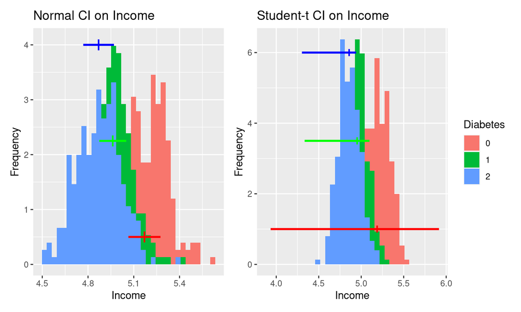

## BMI

Normal CI on BMI

|  | mean | lower | upper |
| --- | --- | --- | --- |
| No Diabetes | 28.417 | 28.202 | 28.632 |
| Pre-Diabetes | 32.908 | 32.660 | 33.155 |
| Diabetes | 29.250 | 29.015 | 29.485 |

Student-t CI on BMI

|  | mean | lower | upper |
| --- | --- | --- | --- |
| No Diabetes | 28.398 | 28.327 | 29.998 |
| Pre-Diabetes | 32.925 | 31.371 | 35.550 |
| Diabetes | 29.285 | 25.541 | 31.141 |

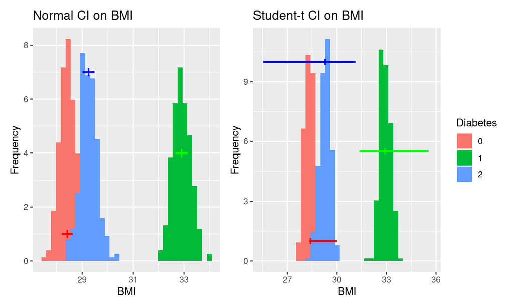

## GenHlth

Normal CI on GenHlth

|  | mean | lower | upper |
| --- | --- | --- | --- |
| No Diabetes | 2.873 | 2.823 | 2.923 |
| Pre-Diabetes | 3.596 | 3.546 | 3.646 |
| Diabetes | 3.037 | 2.979 | 3.094 |

Student-t CI on GenHlth

|  | mean | lower | upper |
| --- | --- | --- | --- |
| No Diabetes | 2.860 | 2.461 | 3.519 |
| Pre-Diabetes | 3.585 | 3.093 | 4.431 |
| Diabetes | 3.051 | 2.641 | 3.148 |

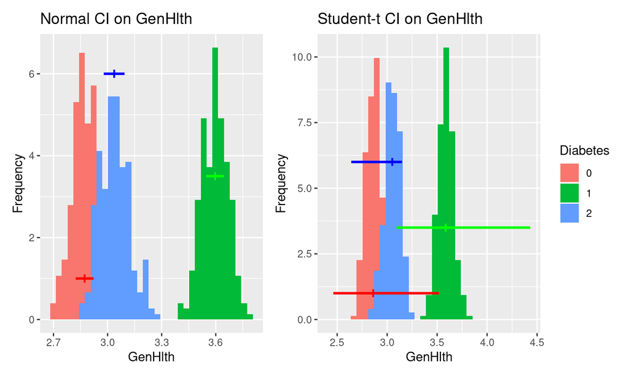

## HighBP

Normal CI on HighBP

|  | mean | lower | upper |
| --- | --- | --- | --- |
| No Diabetes | 0.591 | 0.569 | 0.613 |
| Pre-Diabetes | 0.637 | 0.615 | 0.659 |
| Diabetes | 0.863 | 0.848 | 0.878 |

Student-t CI on HighBP

|  | mean | lower | upper |
| --- | --- | --- | --- |
| No Diabetes | 0.590 | 0.437 | 0.884 |
| Pre-Diabetes | 0.634 | 0.577 | 0.707 |
| Diabetes | 0.866 | 0.801 | 1.060 |

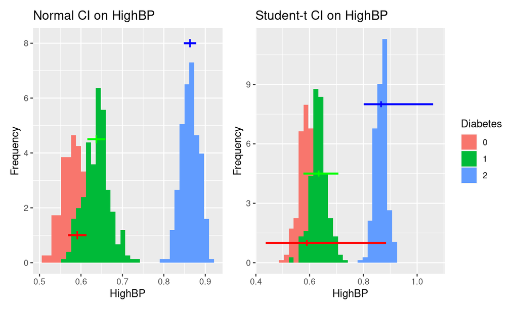

## AnyHealthcare

Normal CI on AnyHealthcare

|  | mean | lower | upper |
| --- | --- | --- | --- |
| No Diabetes | 0.954 | 0.944 | 0.963 |
| Pre-Diabetes | 0.956 | 0.947 | 0.964 |
| Diabetes | 1.000 | 1.000 | 1.000 |

Student-t CI on AnyHealthcare

|  | mean | lower | upper |
| --- | --- | --- | --- |
| No Diabetes | 0.955 | 0.939 | 0.998 |
| Pre-Diabetes | 0.954 | 0.937 | 1.002 |
| Diabetes | 1.000 | NaN | NaN |

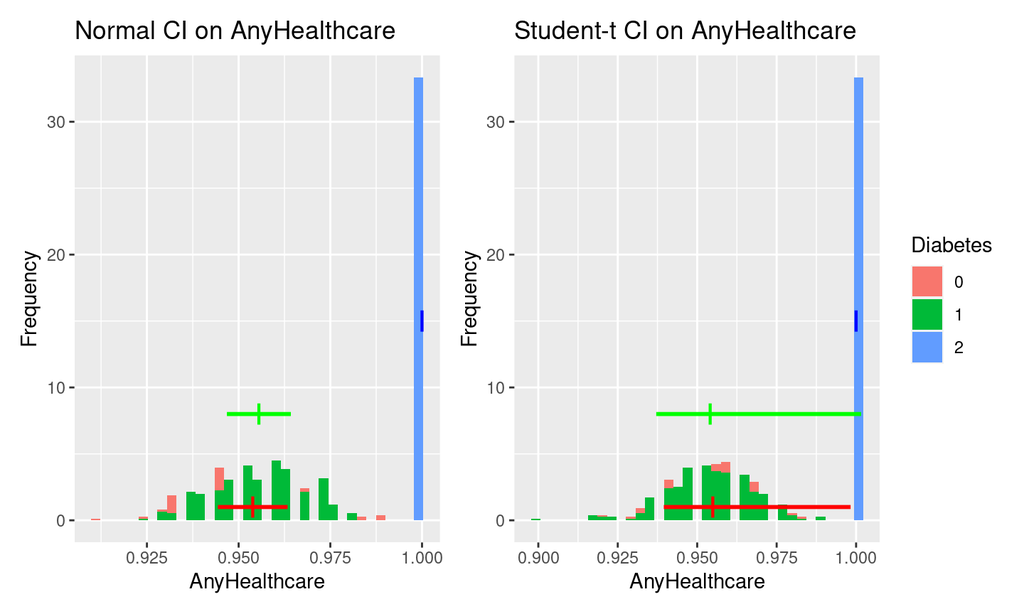

## Normal and Student-t Bootstrap Analysis

- Across all factors, we saw that the Normal CIs were much smaller than Student-t CIs
- Each factor had about a normal distribution of means
- 26 minutes!!

## Caedon BCa bootstrap

Bias Corrected and Accelerated Confidence Intervals

Early struggles + acceleration constant

BCa by hand

Histograms + BCa confidence intervals

## BCa by hand

I used the equation:

\(g(u) = \hat{F}^{-1}(\phi(z_0 + \frac{z_0 + z_u}{1-a(z_0+z_u)}))\)

Lower bound = \(g(\alpha/2)\), Upper bound = \(g(1-\alpha/2)\) \(\phi\) is the standard normal cdf \(\hat{F}\) is the bootstrap cdf \(z_0 = \phi^{-1}F(\hat{\theta})\), quantile of mean of theta_boot <= theta_hat \(z_u = \phi^{-1}(u)\), quantiles of our desired bounds

\(\hat{a} = \frac{1}{6}\frac{\sum_{i=1}^n I_i^3}{(\sum_{i=1}^n I_i^2)^{3/2}}\)

\(I_i = (n-1)(\hat{\theta}-\hat{\theta}_{-i})\) finite sample jacknife approx.

## BCa High Blood Pressure

High Blood Pressure m=50 n=250

|  | Mean | SD | CI_Low | CI_High |
| --- | --- | --- | --- | --- |
| No Diabetes | 0.371 | 0.483 | 0.320 | 0.430 |
| Pre Diabetes | 0.638 | 0.480 | 0.532 | 0.700 |
| Diabetes | 0.761 | 0.426 | 0.693 | 0.798 |

High Blood Pressure m=5 n=10

|  | Mean | SD | CI_Low | CI_High |
| --- | --- | --- | --- | --- |
| No Diabetes | 0.38 | 0.500 | 0.2 | 0.400 |
| Pre Diabetes | 0.66 | 0.491 | 0.6 | 0.797 |
| Diabetes | 0.74 | 0.438 | 0.6 | 0.871 |

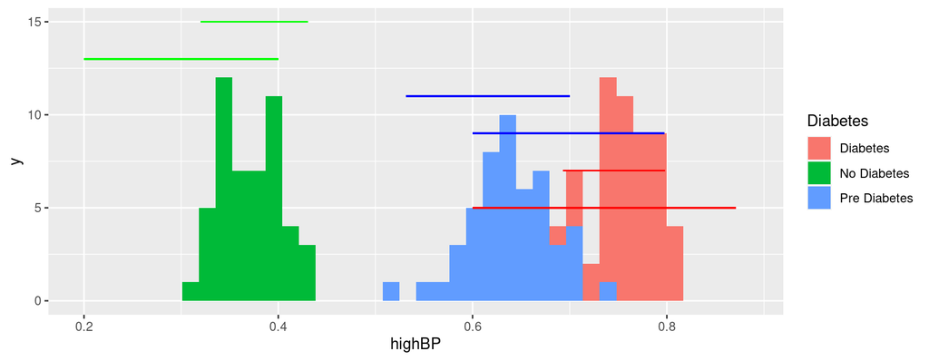

## BCa High Cholesterol

High Cholesterol m=50 n=250

|  | Mean | SD | CI_Low | CI_High |
| --- | --- | --- | --- | --- |
| No Diabetes | 0.378 | 0.485 | 0.310 | 0.436 |
| Pre Diabetes | 0.626 | 0.484 | 0.558 | 0.668 |
| Diabetes | 0.671 | 0.470 | 0.620 | 0.705 |

High Cholesterol m=5 n=10

|  | Mean | SD | CI_Low | CI_High |
| --- | --- | --- | --- | --- |
| No Diabetes | 0.44 | 0.512 | 0.300 | 0.444 |
| Pre Diabetes | 0.64 | 0.503 | 0.600 | 0.700 |
| Diabetes | 0.56 | 0.512 | 0.556 | 0.700 |

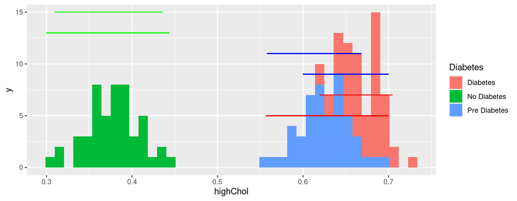

## BCa BMI

BMI m=50 n=250

|  | Mean | SD | CI_Low | CI_High |
| --- | --- | --- | --- | --- |
| No Diabetes | 27.670 | 6.096 | 27.141 | 28.568 |
| Pre Diabetes | 30.754 | 6.848 | 29.911 | 31.514 |
| Diabetes | 32.007 | 7.413 | 31.105 | 32.712 |

BMI m=5 n=10

|  | Mean | SD | CI_Low | CI_High |
| --- | --- | --- | --- | --- |
| No Diabetes | 28.98 | 5.76 | 26.716 | 30.737 |
| Pre Diabetes | 31.14 | 7.82 | 29.430 | 32.042 |
| Diabetes | 31.24 | 7.65 | 30.895 | 32.500 |

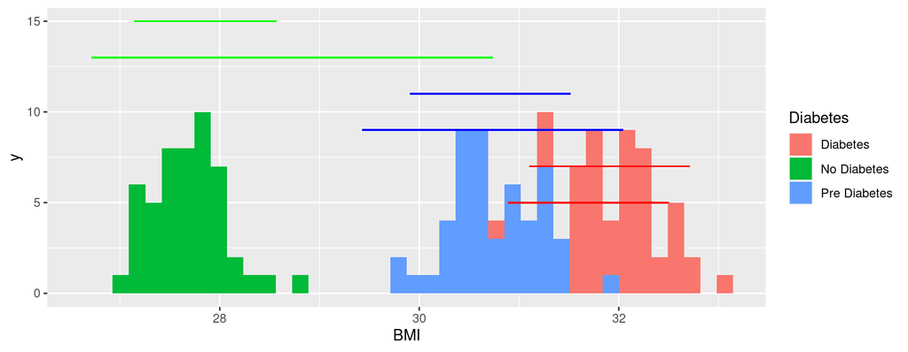

## BCa Any Healthcare

Any Healthcare m=50 n=250

|  | Mean | SD | CI_Low | CI_High |
| --- | --- | --- | --- | --- |
| No Diabetes | 0.949 | 0.217 | 0.918 | 0.976 |
| Pre Diabetes | 0.941 | 0.235 | 0.932 | 0.968 |
| Diabetes | 0.959 | 0.197 | 0.948 | 0.980 |

Any Healthcare m=5 n=10

|  | Mean | SD | CI_Low | CI_High |
| --- | --- | --- | --- | --- |
| No Diabetes | 0.94 | 0.148 | 0.803 | 1 |
| Pre Diabetes | 0.94 | 0.148 | 0.803 | 1 |
| Diabetes | 0.92 | 0.211 | 0.829 | 1 |

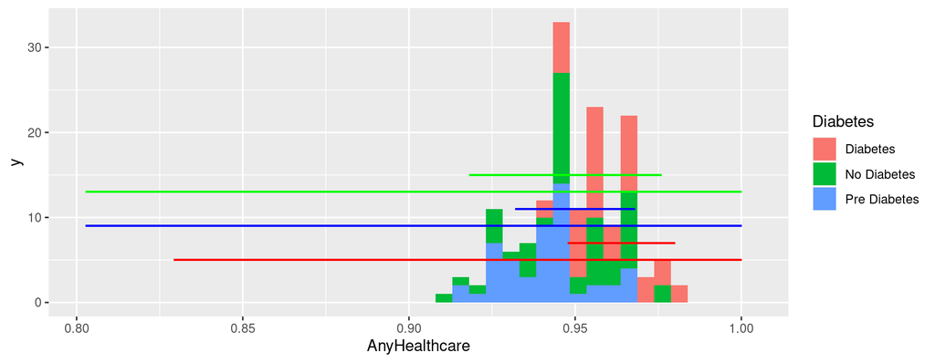

## BCa General Health

General Health m=50 n=250

|  | Mean | SD | CI_Low | CI_High |
| --- | --- | --- | --- | --- |
| No Diabetes | 2.374 | 1.018 | 2.265 | 2.455 |
| Pre Diabetes | 2.971 | 1.028 | 2.841 | 3.108 |
| Diabetes | 3.311 | 1.011 | 3.169 | 3.363 |

General Health m=5 n=10

[output not shown]

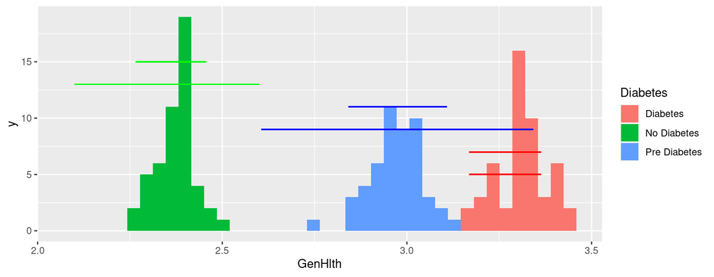

## BCa Income

Income m=50 n=250

[output not shown]

Income m=5 n=10

[output not shown]

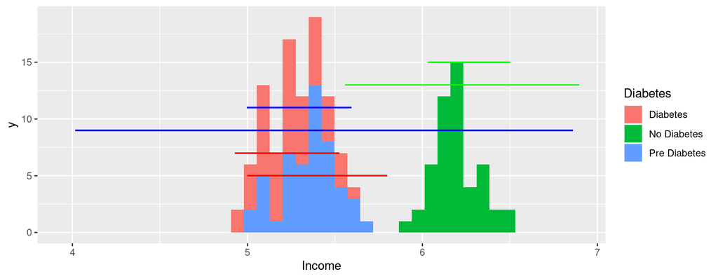

## Conclusion

No-Pre Difference in Means

|  | Income | BMI | GenHlth | HighBP | Hlthcare | HighChol |
| --- | --- | --- | --- | --- | --- | --- |
| Percentile | TRUE | TRUE | TRUE | TRUE | FALSE | TRUE |
| Basic | TRUE | TRUE | TRUE | TRUE | FALSE | TRUE |
| Normal | TRUE | TRUE | TRUE | TRUE | FALSE | TRUE |
| Student-t | FALSE | TRUE | FALSE | FALSE | FALSE | TRUE |
| BCa | TRUE | TRUE | TRUE | TRUE | FALSE | TRUE |

Pre-Diab Difference in Means

[output not shown]

No-Diab Difference in Means

|  | Income | BMI | GenHlth | HighBP | Hlthcare | HighChol |
| --- | --- | --- | --- | --- | --- | --- |
| Percentile | FALSE | TRUE | TRUE | TRUE | TRUE | TRUE |
| Basic | TRUE | TRUE | TRUE | TRUE | TRUE | TRUE |
| Normal | TRUE | TRUE | TRUE | TRUE | TRUE | TRUE |
| Student-t | FALSE | FALSE | FALSE | FALSE | TRUE | FALSE |
| BCa | TRUE | TRUE | TRUE | TRUE | FALSE | TRUE |